# Math189Pr_3

# Visulization of palindrome counts distribution

Group the data by dividing the interval [0,N] into 61 sub-intervals and count how many data points are inside each of them. Using graphical methods to compare a generated Poisson sequence and the distribution of the palindromes counts in different sets of location intervals. Remark: The pink histogram and the red density curve represents the distribution and density for actual data. The light blue histogram and the blue density curve represents distribution for generated Poisson sequence. The purple histogram represents the overlapped area.

```r
k <- 61
tab <- table(cut(locations, breaks = seq(0, N, length.out = k+1), include.lowest = TRUE))
counts <- as.vector(tab)
counts
```

```
##  [1]  7  1  4  4  5  6  4  1  4  6  4  3  5  4  6  3  8  6  4  5  7  1  7
## [24]  3 17  3  4  5  3  2  5  5  3  6  4  3 10  4  5  7  5  4  2  7  7  4
## [47]  5  6  1  4  8 10  6  3  3  6  0  5  2  7  7
```

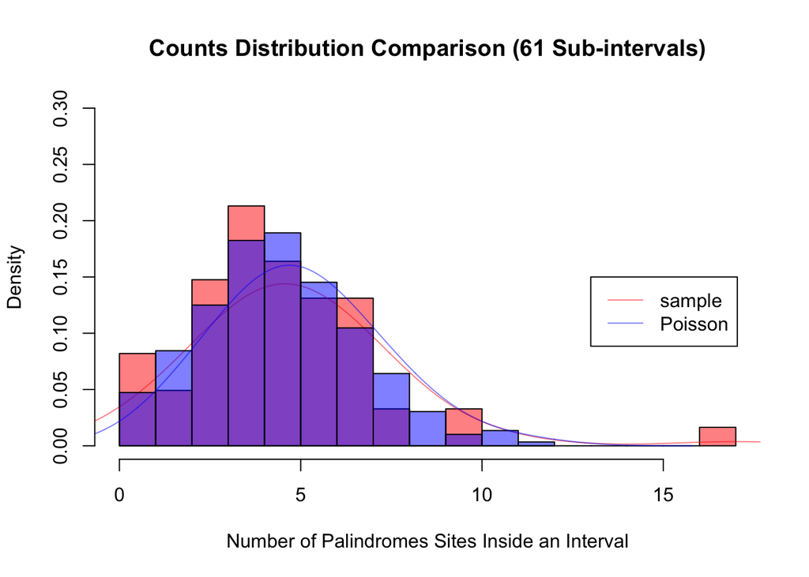

```r
hist(counts, breaks = 15, col = rgb(1,0,0,0.5), probability = TRUE, main = "Counts Distribution Comparison (61 Sub-intervals)", xlab = "Number of Palindromes Sites Inside an Interval", ylim = c(0,0.3))
lines(density(counts, adjust = 2), col = rgb(1,0,0,0.5))
Pois <- rpois(n, lambda = mean(counts))
hist(Pois, breaks = 15, col = rgb(0,0,1,0.5), probability = TRUE, add = TRUE)
lines(density(Pois, adjust = 2), col = rgb(0,0,1,0.5))
legend(x = 13, y = 0.15, legend = c("sample", "Poisson"), lty = c(1,1), col = c(rgb(1,0,0,0.5), rgb(0,0,1,0.5)))
```

# Additional testings on using different lengths of sub-intervals:

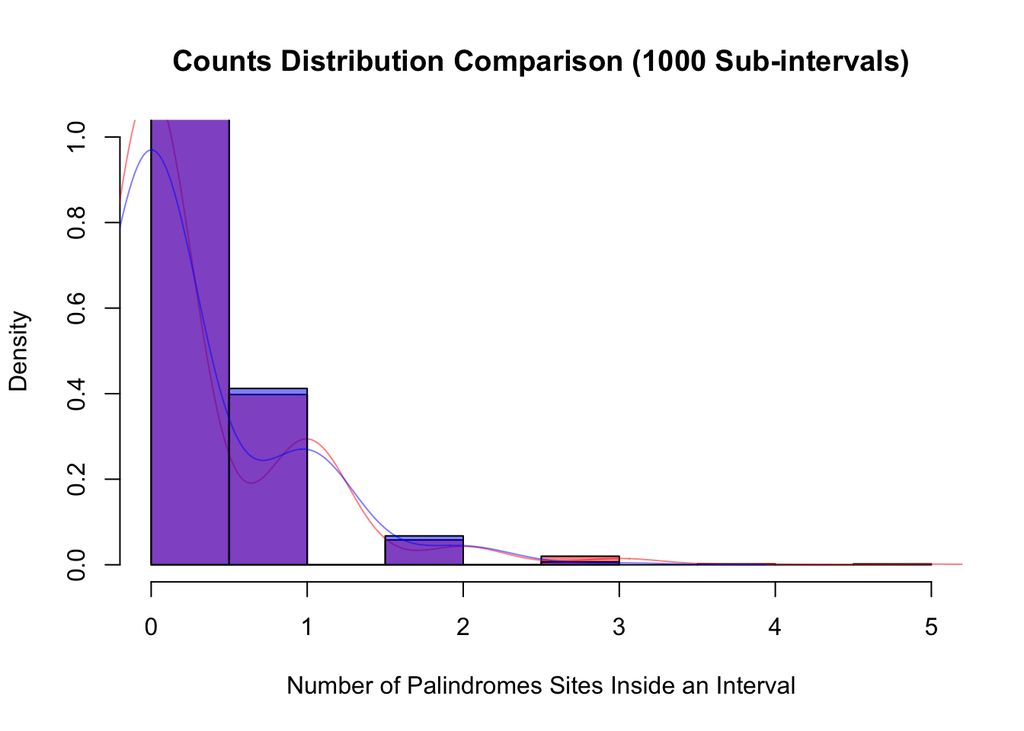

```r
j <- 1000
tab <- table(cut(locations, breaks = seq(0, N, length.out = j+1), include.lowest = TRUE))
counts <- as.vector(tab)
hist(counts, breaks = 10, col = rgb(1,0,0,0.5), probability = TRUE, main = "Counts Distribution Comparison (1000 Sub-intervals)", xlab = "Number of Palindromes Sites Inside an Interval", ylim = c(0,1))
lines(density(counts, adjust = 2), col = rgb(1,0,0,0.5))
Pois <- rpois(n, lambda = mean(counts))
hist(Pois, breaks = 10, col = rgb(0,0,1,0.5), probability = TRUE, add = TRUE)
lines(density(Pois, adjust = 2), col = rgb(0,0,1,0.5))
legend(x = 32, y = 0.17, legend = c("sample", "Poisson"), lty = c(1,1), col = c(rgb(1,0,0,0.5), rgb(0,0,1,0.5)))
```

```r
j <- 45
tab <- table(cut(locations, breaks = seq(0, N, length.out = j+1), include.lowest = TRUE))
counts <- as.vector(tab)
counts
```

```
##  [1]  7  4  5  9  5  3  7  4  6  4 10  5 11  5 11  2  7  7 15  5  6  4  6
## [24]  7  5  6  9  7  8  9  4  5  8  7  7  5  6  8 14  3  7  2  5  8  8
```

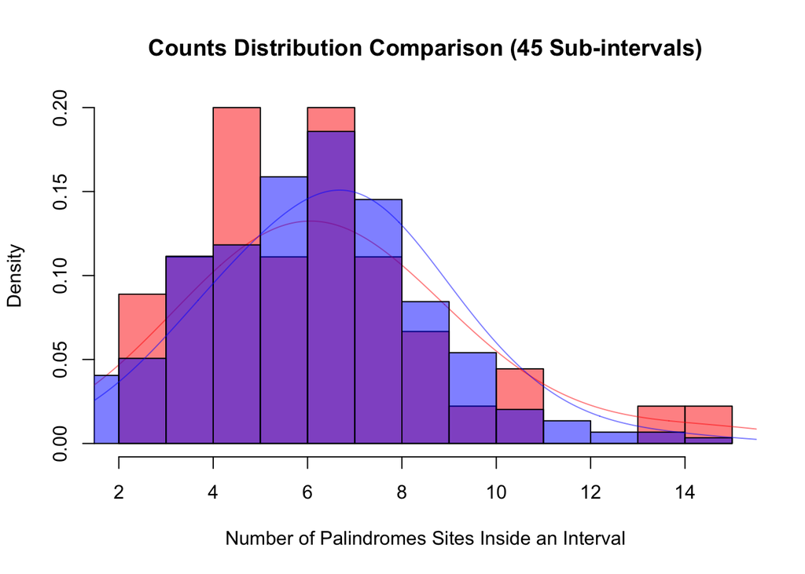

```r
hist(counts, breaks = 15, col = rgb(1,0,0,0.5), probability = TRUE, main = "Counts Distribution Comparison (45 Sub-intervals)", xlab = "Number of Palindromes Sites Inside an Interval", ylim = c(0,0.2))
lines(density(counts, adjust = 2), col = rgb(1,0,0,0.5))
Pois <- rpois(n, lambda = mean(counts))
hist(Pois, breaks = 15, col = rgb(0,0,1,0.5), probability = TRUE, add = TRUE)
lines(density(Pois, adjust = 2), col = rgb(0,0,1,0.5))
legend(x = 20, y = 0.15, legend = c("sample", "Poisson"), lty = c(1,1), col = c(rgb(1,0,0,0.5), rgb(0,0,1,0.5)))
```

```r
j <- 27
tab <- table(cut(locations, breaks = seq(0, N, length.out = j+1), include.lowest = TRUE))
tab
```

```
##
##        [0,8.49e+03]  (8.49e+03,1.7e+04]  (1.7e+04,2.55e+04]
##                   8                  12                  10
##  (2.55e+04,3.4e+04]  (3.4e+04,4.25e+04]  (4.25e+04,5.1e+04]
##                   6                  11                   7
##  (5.1e+04,5.95e+04]  (5.95e+04,6.8e+04]  (6.8e+04,7.65e+04]
##                  12                  15                  15
## (7.65e+04,8.49e+04] (8.49e+04,9.34e+04] (9.34e+04,1.02e+05]
##                   3                  24                   9
##  (1.02e+05,1.1e+05]  (1.1e+05,1.19e+05] (1.19e+05,1.27e+05]
##                  10                   7                  11
## (1.27e+05,1.36e+05] (1.36e+05,1.44e+05] (1.44e+05,1.53e+05]
##                   9                  18                  12
## (1.53e+05,1.61e+05]  (1.61e+05,1.7e+05]  (1.7e+05,1.78e+05]
##                   6                  14                  11
## (1.78e+05,1.87e+05] (1.87e+05,1.95e+05] (1.95e+05,2.04e+05]
##                   8                  19                   9
## (2.04e+05,2.12e+05] (2.12e+05,2.21e+05] (2.21e+05,2.29e+05]
##                   9                   6                  15
```

```r
counts <- as.vector(tab)
counts
```

```
##  [1]  8 12 10  6 11  7 12 15 15  3 24  9 10  7 11  9 18 12  6 14 11  8 19
## [24]  9  9  6 15
```

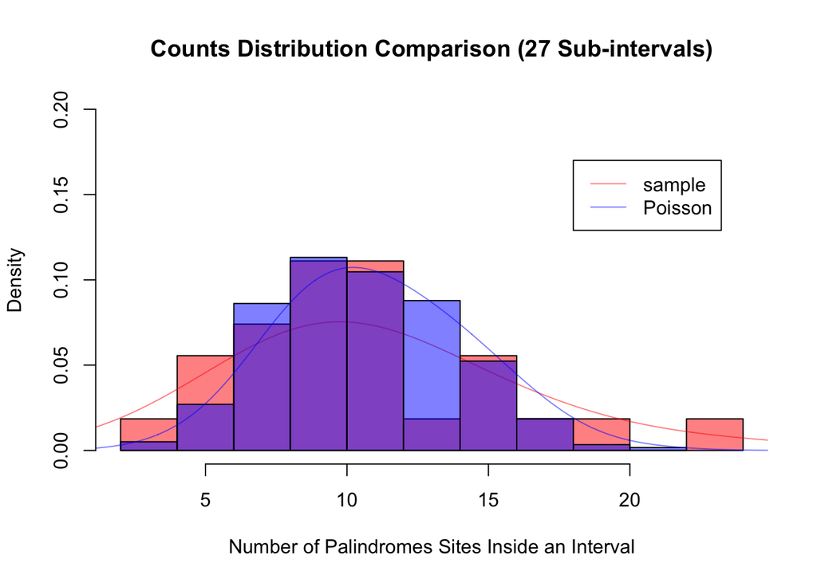

```r
hist(counts, breaks = 10, col = rgb(1,0,0,0.5), probability = TRUE, main = "Counts Distribution Comparison (27 Sub-intervals)", xlab = "Number of Palindromes Sites Inside an Interval", ylim = c(0,0.2))
lines(density(counts, adjust = 2), col = rgb(1,0,0,0.5))
Pois <- rpois(n, lambda = mean(counts))
hist(Pois, breaks = 10, col = rgb(0,0,1,0.5), probability = TRUE, add = TRUE)
lines(density(Pois, adjust = 2), col = rgb(0,0,1,0.5))
legend(x = 18, y = 0.17, legend = c("sample", "Poisson"), lty = c(1,1), col = c(rgb(1,0,0,0.5), rgb(0,0,1,0.5)))
```